# Case study of a Cyclistic (Divvy) bike share data

Shibin Shahid K V

2022-10-29

This is a case study done as part of Google Data Analytics Capstone: Case study of a Cyclistic (Divvy) bike share data. The bike share data from October 2021 to September 2022 is used for analysing the trend.

Installing the required packages

```r
install.packages("tidyverse", repos = "http://cran.us.r-project.org ")  # tidyverse for data import and wrangling
install.packages("lubridate", repos = "http://cran.us.r-project.org ")  # lubridate for date functions
install.packages("ggplot2", repos = "http://cran.us.r-project.org ")    # ggplot for visualization
install.packages("readxl", repos = "http://cran.us.r-project.org ")     # readxl for uploading excel files
install.packages("janitor", repos = "http://cran.us.r-project.org ")    # for cleaning
```

Load the packages

```r
library(tidyverse)  #helps wrangle data
library(lubridate)  #helps wrangle date attributes
library(ggplot2)    #helps visualize data
library(readxl)     #helps to read excel file
library(janitor)
```

#### STEP 1: COLLECT DATA

The source for downloading the data is from the [link](https://divvy-tripdata.s3.amazonaws.com/index.html). *I have done the analysis from October 2021 to September 2022.* Upload Divvy datasets (xlsx files) here. *Here I have added columns for ride_length and day_of_week from excel sheet itself.

```r
tripdata_2021_oct <- read_excel('202110-divvy-tripdata.xlsx')
tripdata_2021_nov <- read_excel('202111-divvy-tripdata.xlsx')
tripdata_2021_dec <- read_excel('202112-divvy-tripdata.xlsx')
tripdata_2022_jan <- read_excel('202201-divvy-tripdata.xlsx')
tripdata_2022_feb <- read_excel('202202-divvy-tripdata.xlsx')
tripdata_2022_mar <- read_excel('202203-divvy-tripdata.xlsx')
tripdata_2022_apr <- read_excel('202204-divvy-tripdata.xlsx')
tripdata_2022_may <- read_excel('202205-divvy-tripdata.xlsx')
tripdata_2022_jun <- read_excel('202206-divvy-tripdata.xlsx')
tripdata_2022_jul <- read_excel('202207-divvy-tripdata.xlsx')
tripdata_2022_aug <- read_excel('202208-divvy-tripdata.xlsx')
tripdata_2022_sep <- read_excel('202209-divvy-tripdata.xlsx')
```

#### STEP 2: WRANGLE DATA AND COMBINE INTO A SINGLE FILE

*Compare column names of each of the files.* checking the datatypes are consistent in all sheets. For example, the first and last data is shown.

```r
str(tripdata_2021_oct)
```

```
## tibble [631,226 × 15] (S3: tbl_df/tbl/data.frame)
##  $ ride_id           : chr [1:631226] "620BC6107255BF4C" "4471C70731AB2E45" "26CA69D43D15EE14" "362947F0437E1514" ...
##  $ rideable_type     : chr [1:631226] "electric_bike" "electric_bike" "electric_bike" "electric_bike" ...
##  $ started_at        : POSIXct[1:631226], format: "2021-10-22 12:46:42" "2021-10-21 09:12:37" ...
##  $ ended_at          : POSIXct[1:631226], format: "2021-10-22 12:49:50" "2021-10-21 09:14:14" ...
##  $ start_station_name: chr [1:631226] "Kingsbury St & Kinzie St" NA NA NA ...
##  $ start_station_id  : chr [1:631226] "KA1503000043" NA NA NA ...
##  $ end_station_name  : chr [1:631226] NA NA NA NA ...
##  $ end_station_id    : chr [1:631226] NA NA NA NA ...
##  $ start_lat         : num [1:631226] 41.9 41.9 41.9 41.9 41.9 ...
##  $ start_lng         : num [1:631226] -87.6 -87.7 -87.7 -87.7 -87.7 ...
##  $ end_lat           : num [1:631226] 41.9 41.9 41.9 41.9 41.9 ...
##  $ end_lng           : num [1:631226] -87.6 -87.7 -87.7 -87.7 -87.7 ...
##  $ member_casual     : chr [1:631226] "member" "member" "member" "member" ...
##  $ ride_length       : POSIXct[1:631226], format: "1899-12-31 00:03:08" "1899-12-31 00:01:37" ...
##  $ day_of_week       : num [1:631226] 6 5 7 7 4 5 5 4 5 4 ...
```

```r
str(tripdata_2021_oct)
str(tripdata_2021_nov)
str(tripdata_2021_dec)
str(tripdata_2022_jan)
str(tripdata_2022_feb)
str(tripdata_2022_mar)
str(tripdata_2022_apr)
str(tripdata_2022_may)
str(tripdata_2022_jun)
str(tripdata_2022_jul)
str(tripdata_2022_aug)
str(tripdata_2022_sep) # end_station_id was found to be in num data type. so it has to be converted to chr
```

```r
str(tripdata_2022_sep)
```

```
## tibble [701,339 × 15] (S3: tbl_df/tbl/data.frame)
##  $ ride_id           : chr [1:701339] "5156990AC19CA285" "E12D4A16BF51C274" "A02B53CD7DB72DD7" "C82E05FEE872DF11" ...
##  $ rideable_type     : chr [1:701339] "electric_bike" "electric_bike" "electric_bike" "electric_bike" ...
##  $ started_at        : POSIXct[1:701339], format: "2022-09-01 08:36:22" "2022-09-01 17:11:29" ...
##  $ ended_at          : POSIXct[1:701339], format: "2022-09-01 08:39:05" "2022-09-01 17:14:45" ...
##  $ start_station_name: chr [1:701339] NA NA NA NA ...
##  $ start_station_id  : chr [1:701339] NA NA NA NA ...
##  $ end_station_name  : chr [1:701339] "California Ave & Milwaukee Ave" NA NA NA ...
##  $ end_station_id    : num [1:701339] 13084 NA NA NA NA ...
##  $ start_lat         : num [1:701339] 41.9 41.9 41.9 41.9 41.9 ...
##  $ start_lng         : num [1:701339] -87.7 -87.6 -87.6 -87.7 -87.7 ...
##  $ end_lat           : num [1:701339] 41.9 41.9 41.9 41.9 41.9 ...
##  $ end_lng           : num [1:701339] -87.7 -87.6 -87.6 -87.7 -87.7 ...
##  $ member_casual     : chr [1:701339] "casual" "casual" "casual" "casual" ...
##  $ ride_length       : POSIXct[1:701339], format: "1899-12-31 00:02:43" "1899-12-31 00:03:16" ...
##  $ day_of_week       : num [1:701339] 5 5 5 5 5 5 5 5 5 5 ...
```

converting end_station_id of sep_2022 to chr

```r
tripdata_2022_sep <- mutate(tripdata_2022_sep,
  end_station_id = as.character(end_station_id))
```

Combining the 12 months data into 1 dataframe

```r
tripdata_combined <- bind_rows(
                              tripdata_2021_oct,
                              tripdata_2021_nov,
                              tripdata_2021_dec,
                              tripdata_2022_jan,
                              tripdata_2022_feb,
                              tripdata_2022_mar,
                              tripdata_2022_apr,
                              tripdata_2022_may,
                              tripdata_2022_jun,
                              tripdata_2022_jul,
                              tripdata_2022_aug,
                              tripdata_2022_sep
                              )
```

#### STEP 3: CLEAN UP AND ADD DATA TO PREPARE FOR ANALYSIS

Inspect the new table that has been created

```r
colnames(tripdata_combined) #List of column names
```

```
##  [1] "ride_id"            "rideable_type"      "started_at"
##  [4] "ended_at"           "start_station_name" "start_station_id"
##  [7] "end_station_name"   "end_station_id"     "start_lat"
## [10] "start_lng"          "end_lat"            "end_lng"
## [13] "member_casual"      "ride_length"        "day_of_week"
```

```r
nrow(tripdata_combined)     #How many rows are in data frame?
```

```
## [1] 5828235
```

```r
dim(tripdata_combined)      #Dimensions of the data frame?
```

```
## [1] 5828235      15
```

```r
head(tripdata_combined)     #See the first 6 rows of data frame.  Also tail(all_trips)
```

```
## # A tibble: 6 × 15
##   ride_id        ridea…¹ started_at          ended_at            start…² start…³
##   <chr>          <chr>   <dttm>              <dttm>              <chr>   <chr>
## 1 620BC6107255B… electr… 2021-10-22 12:46:42 2021-10-22 12:49:50 Kingsb… KA1503…
## 2 4471C70731AB2… electr… 2021-10-21 09:12:37 2021-10-21 09:14:14 <NA>    <NA>
## 3 26CA69D43D15E… electr… 2021-10-16 16:28:39 2021-10-16 16:36:26 <NA>    <NA>
## 4 362947F0437E1… electr… 2021-10-16 16:17:48 2021-10-16 16:19:03 <NA>    <NA>
## 5 BB731DE2F2EC5… electr… 2021-10-20 23:17:54 2021-10-20 23:26:10 <NA>    <NA>
## 6 7176307BBC097… electr… 2021-10-21 16:57:37 2021-10-21 17:11:58 <NA>    <NA>
## # … with 9 more variables: end_station_name <chr>, end_station_id <chr>,
## #   start_lat <dbl>, start_lng <dbl>, end_lat <dbl>, end_lng <dbl>,
## #   member_casual <chr>, ride_length <dttm>, day_of_week <dbl>, and abbreviated
## #   variable names ¹rideable_type, ²start_station_name, ³start_station_id
```

```r
str(tripdata_combined)      #See list of columns and data types (numeric, character, etc)
```

```
## tibble [5,828,235 × 15] (S3: tbl_df/tbl/data.frame)
##  $ ride_id           : chr [1:5828235] "620BC6107255BF4C" "4471C70731AB2E45" "26CA69D43D15EE14" "362947F0437E1514" ...
##  $ rideable_type     : chr [1:5828235] "electric_bike" "electric_bike" "electric_bike" "electric_bike" ...
##  $ started_at        : POSIXct[1:5828235], format: "2021-10-22 12:46:42" "2021-10-21 09:12:37" ...
##  $ ended_at          : POSIXct[1:5828235], format: "2021-10-22 12:49:50" "2021-10-21 09:14:14" ...
##  $ start_station_name: chr [1:5828235] "Kingsbury St & Kinzie St" NA NA NA ...
##  $ start_station_id  : chr [1:5828235] "KA1503000043" NA NA NA ...
##  $ end_station_name  : chr [1:5828235] NA NA NA NA ...
##  $ end_station_id    : chr [1:5828235] NA NA NA NA ...
##  $ start_lat         : num [1:5828235] 41.9 41.9 41.9 41.9 41.9 ...
##  $ start_lng         : num [1:5828235] -87.6 -87.7 -87.7 -87.7 -87.7 ...
##  $ end_lat           : num [1:5828235] 41.9 41.9 41.9 41.9 41.9 ...
##  $ end_lng           : num [1:5828235] -87.6 -87.7 -87.7 -87.7 -87.7 ...
##  $ member_casual     : chr [1:5828235] "member" "member" "member" "member" ...
##  $ ride_length       : POSIXct[1:5828235], format: "1899-12-31 00:03:08" "1899-12-31 00:01:37" ...
##  $ day_of_week       : num [1:5828235] 6 5 7 7 4 5 5 4 5 4 ...
```

```r
summary(tripdata_combined)  #Statistical summary of data. Mainly for numerics
```

```
##    ride_id          rideable_type        started_at
##  Length:5828235     Length:5828235     Min.   :2021-10-01 00:00:09.00
##  Class :character   Class :character   1st Qu.:2022-02-28 19:21:08.50
##  Mode  :character   Mode  :character   Median :2022-06-08 06:41:28.00
##                                        Mean   :2022-05-06 21:39:18.18
##                                        3rd Qu.:2022-08-02 11:26:01.00
##                                        Max.   :2022-09-30 23:59:56.00
##
##     ended_at                     start_station_name start_station_id
##  Min.   :2021-10-01 00:03:11.0   Length:5828235     Length:5828235
##  1st Qu.:2022-02-28 19:34:02.5   Class :character   Class :character
##  Median :2022-06-08 06:55:07.0   Mode  :character   Mode  :character
##  Mean   :2022-05-06 21:58:54.2
##  3rd Qu.:2022-08-02 11:46:26.0
##  Max.   :2022-10-05 19:53:11.0
##
##  end_station_name   end_station_id       start_lat       start_lng
##  Length:5828235     Length:5828235     Min.   :41.64   Min.   :-87.84
##  Class :character   Class :character   1st Qu.:41.88   1st Qu.:-87.66
##  Mode  :character   Mode  :character   Median :41.90   Median :-87.64
##                                        Mean   :41.90   Mean   :-87.65
##                                        3rd Qu.:41.93   3rd Qu.:-87.63
##                                        Max.   :45.64   Max.   :-73.80
##
##     end_lat         end_lng       member_casual
##  Min.   :41.39   Min.   :-88.97   Length:5828235
##  1st Qu.:41.88   1st Qu.:-87.66   Class :character
##  Median :41.90   Median :-87.64   Mode  :character
##  Mean   :41.90   Mean   :-87.65
##  3rd Qu.:41.93   3rd Qu.:-87.63
##  Max.   :42.37   Max.   :-87.30
##  NA's   :5844    NA's   :5844
##   ride_length                      day_of_week
##  Min.   :1899-12-30 21:42:35.00   Min.   :1.000
##  1st Qu.:1899-12-31 00:05:56.00   1st Qu.:2.000
##  Median :1899-12-31 00:10:29.00   Median :4.000
##  Mean   :1899-12-31 00:19:37.23   Mean   :4.117
##  3rd Qu.:1899-12-31 00:18:51.00   3rd Qu.:6.000
##  Max.   :1900-01-28 06:25:01.00   Max.   :7.000
##  NA's   :1
```

Finding the ride_length and converting into seconds

```r
tripdata_combined$ride_length <- difftime(
                                          tripdata_combined$ended_at,
                                          tripdata_combined$started_at,
                                          units = "secs"
                                          )
```

converting ride_length data type from ‘difftime’ num to num

```r
tripdata_combined$ride_length <- as.numeric(tripdata_combined$ride_length)
```

Add columns that list the date, month, day, and year of each ride This will allow us to aggregate ride data for each month, day, or year .before completing these operations we could only aggregate at the ride level

```r
tripdata_combined$date <- as.Date(tripdata_combined$started_at)               #The default format is yyyy-mm-dd
tripdata_combined$month <- format(as.Date(tripdata_combined$date), "%m")
tripdata_combined$day <- format(as.Date(tripdata_combined$date), "%d")
tripdata_combined$year <- format(as.Date(tripdata_combined$date), "%Y")
tripdata_combined$day_of_week <- format(as.Date(tripdata_combined$date), "%A")
```

```r
all_trips <- tripdata_combined %>% filter(ride_length>=0) %>% filter(start_station_name != "HQ QR")
```

#### STEP 4: CONDUCT DESCRIPTIVE ANALYSIS

Descriptive analysis on ride_length (all figures in seconds)

```r
mean(all_trips$ride_length) #straight average (total ride length / rides)
```

```
## [1] 1243.658
```

```r
median(all_trips$ride_length) #midpoint number in the ascending array of ride lengths
```

```
## [1] 644
```

```r
max(all_trips$ride_length) #longest ride
```

```
## [1] 2442301
```

```r
min(all_trips$ride_length) #shortest ride
```

```
## [1] 0
```

Compare members and casual users

```r
aggregate(all_trips$ride_length ~ all_trips$member_casual, FUN = mean)
```

```
##   all_trips$member_casual all_trips$ride_length
## 1                  casual             1915.3672
## 2                  member              775.0878
```

```r
aggregate(all_trips$ride_length ~ all_trips$member_casual, FUN = median)
```

```
##   all_trips$member_casual all_trips$ride_length
## 1                  casual                   840
## 2                  member                   542
```

```r
aggregate(all_trips$ride_length ~ all_trips$member_casual, FUN = max)
```

```
##   all_trips$member_casual all_trips$ride_length
## 1                  casual               2442301
## 2                  member                 93594
```

```r
aggregate(all_trips$ride_length ~ all_trips$member_casual, FUN = min)
```

```
##   all_trips$member_casual all_trips$ride_length
## 1                  casual                     0
## 2                  member                     0
```

See the average ride time by each day for members vs casual users

```r
aggregate(all_trips$ride_length ~ all_trips$member_casual + all_trips$day_of_week, FUN = mean)
```

```
##    all_trips$member_casual all_trips$day_of_week all_trips$ride_length
## 1                   casual                Friday             1836.1176
## 2                   member                Friday              759.4998
## 3                   casual                Monday             1943.0161
## 4                   member                Monday              748.7428
## 5                   casual              Saturday             2118.7804
## 6                   member              Saturday              869.4681
## 7                   casual                Sunday             2230.3099
## 8                   member                Sunday              866.0173
## 9                   casual              Thursday             1676.9442
## 10                  member              Thursday              746.5041
## 11                  casual               Tuesday             1686.0902
## 12                  member               Tuesday              737.0860
## 13                  casual             Wednesday             1632.7380
## 14                  member             Wednesday              734.2675
```

Notice that the days of the week are out of order. Let’s fix that.

```r
all_trips$day_of_week <- ordered(all_trips$day_of_week, levels=c("Sunday", "Monday", "Tuesday", "Wednesday", "Thursday", "Friday", "Saturday"))
```

Now, let’s run the average ride time by each day for members vs casual users

```r
aggregate(all_trips$ride_length ~ all_trips$member_casual + all_trips$day_of_week, FUN = mean)
```

```
##    all_trips$member_casual all_trips$day_of_week all_trips$ride_length
## 1                   casual                Sunday             2230.3099
## 2                   member                Sunday              866.0173
## 3                   casual                Monday             1943.0161
## 4                   member                Monday              748.7428
## 5                   casual               Tuesday             1686.0902
## 6                   member               Tuesday              737.0860
## 7                   casual             Wednesday             1632.7380
## 8                   member             Wednesday              734.2675
## 9                   casual              Thursday             1676.9442
## 10                  member              Thursday              746.5041
## 11                  casual                Friday             1836.1176
## 12                  member                Friday              759.4998
## 13                  casual              Saturday             2118.7804
## 14                  member              Saturday              869.4681
```

analyze ridership data by type and weekday

```r
all_trips %>%
  mutate(weekday = wday(started_at, label = TRUE)) %>%  # creates weekday field using wday()
  group_by(member_casual, weekday) %>%                  # groups by usertype and weekday
  summarise(number_of_rides = n()                                   # calculates the number of rides and average duration
            ,average_duration = mean(ride_length)) %>%  # calculates the average duration
  arrange(member_casual, weekday)
```

```
## # A tibble: 14 × 4
## # Groups:   member_casual [2]
##    member_casual weekday number_of_rides average_duration
##    <chr>         <ord>             <int>            <dbl>
##  1 casual        Sun              347491            2230.
##  2 casual        Mon              235875            1943.
##  3 casual        Tue              230115            1686.
##  4 casual        Wed              234628            1633.
##  5 casual        Thu              255488            1677.
##  6 casual        Fri              294181            1836.
##  7 casual        Sat              429369            2119.
##  8 member        Sun              330398             866.
##  9 member        Mon              403761             749.
## 10 member        Tue              464179             737.
## 11 member        Wed              459975             734.
## 12 member        Thu              449707             747.
## 13 member        Fri              413270             759.
## 14 member        Sat              384684             869.
```

Let’s visualize the number of rides by rider type

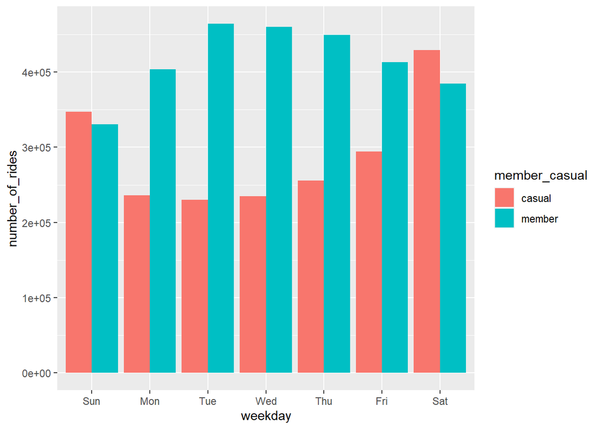

```r
all_trips %>%
  mutate(weekday = wday(started_at, label = TRUE)) %>%
  group_by(member_casual, weekday) %>%
  summarise(number_of_rides = n()
            ,average_duration = mean(ride_length)) %>%
  arrange(member_casual, weekday)  %>%
  ggplot(aes(x = weekday, y = number_of_rides, fill = member_casual)) +
  geom_col(position = "dodge")
```

Let’s create a visualization for average duration

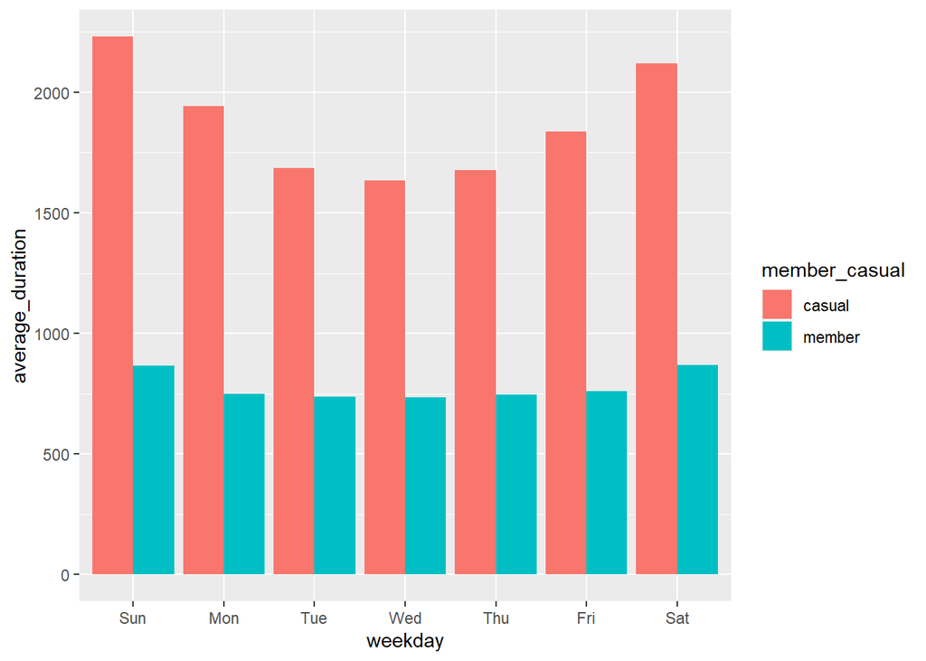

```r
all_trips%>%
  mutate(weekday = wday(started_at, label = TRUE)) %>%
  group_by(member_casual, weekday) %>%
  summarise(number_of_rides = n()
            ,average_duration = mean(ride_length)) %>%
  arrange(member_casual, weekday)  %>%
  ggplot(aes(x = weekday, y = average_duration, fill = member_casual)) +
  geom_col(position = "dodge")
```